# A Package for Processing Argo Float Profiles

*Dan Kelley (https://orcid.org/0000-0001-7808-5911), Jaimie Harbin ( https://orcid.org/0000-0003-3774-3732), and Clark Richards (https://orcid.org/0000-0002-7833-206X)*

## 1. Introduction

The `argoFloats` package provides tools for downloading and processing Argo profile data. It allows users to focus on core, biogeochemical (bgc) , or deep argo profiles, and also allows the user to sift these profiles based on ID, time, geography, and institution. Once downloaded, such datasets can be analysed within `argoFloats` or using other R tools and packages.

## 2. Work flow

The sketch given below illustrates the typical workflow with the package, with descriptions of the steps on the left, and names of the relevant functions on the right.

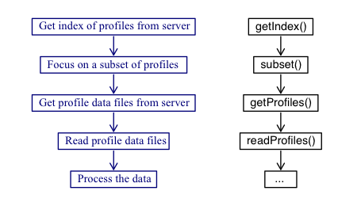

Figure 1: Work flow of the argoFloats package

As illustrated, the central functions are `getIndex()`, `subset()`, `subset,argoFloats-method()`, `getProfiles()`, and `readProfiles()`.

Some built-in datasets are also provided for concreteness of illustration and for testing, but actual work always starts with a call to `getIndex()` to download a full index of float data, which we will demonstrate later in this vignette.

## 3. argoFloats Functions

To begin to get familiar with how the `argoFloats` package works, we will begin looking at the built in data sets. Built into the `argoFloats` package is the `index`, `indexBgc`, and `indexMerged`, referring to core argo, bgc-argo, and a combinaton respectively. For the sake of this vignette we will focus on the `indexMerged` data set.

To begin, the user should first download the following packages (*Hint:* you may have to use the `Sys.setenv(R_REMOTES_NO_ERRORS_FROM_WARNINGS = TRUE)` command if you receive a Zero Exit Status Error):

```
install.packages(devtools)
library(devtools)
install_github('dankelley/argoFloats', ref='develop')
library(argoFloats)
install_github("dankelley/oce", ref='develop')
library(oce)
install_github('dankelley/ocedata', ref='develop')
library(ocedata)
```

To access the embedded data set within `argoFloats`, the following code is used:

```r
data('indexMerged', package='argoFloats')
```

It’s now possible to apply the `argoFloats` specialized versions of R “generic” functions, `plot()`, `[[`, `summary()`, and `show()`.

## 3.1 Plotting the Data

The `plot()` function within the `argoFloats` package provides simple ways to plot aspects of `argoFloats-class` objects. To produce the built in plot and visualize the coordinates of a section of argo floats off of the Bahamas, the following code is used:

```
plot(indexMerged)
```

### 3.2 Extracting Data

`[[` provides a way to extract items from `argoFloats` objects, without getting lost in the details of storage. (Note that `[[<-` is *not* specialized, since the user is highly discouraged from altering values within `argoFloats` objects.). For example, if the user wanted to extract the `parameters` within the `indexMerged` dataset, instead of doing `indexMerged@data$index$parameters`, instead they can simply do `indexMerged[['parameters']]`

### 3.3 Summarizing Data

The `summary()` command displays key features of `argoFloats-class` objects. See `summary,argoFloats-method()` further details.

### 3.4 Showing Information About argoFloats Objects

Lastly, `show()` command provides a one-line sketch of `argoFloats-class` objects. For example if the user types in:

```
indexMerged
```

The following output occurs:

```
argoFloats object of type "index" with 39 items
```

See `show,argoFloats-method()` for details.

It should be noted that the profile elements within `argoFloats` objects are stored as in the form of `argo` objects as defined by the `oce` package. This means that `argoFloats` users can rely on a wide variety of `oce` functions to analyse their data. The full suite of R tools is also available, and the vastness of that suite explains why `argoFloats` is written in R.

# 4. Steps to working with data that is not built in

### 4.1 getIndex()

As shown by Figure 1, the `getIndex()` command is used to get an index of available argo float profiles, either by downloading information from a data repository or by reusing an index (stored as an .rda file) that was prepared by a recent call to the function.

See `?getIndex()` for further description about the further arguments.

To get the indexMerged index from the USGODAE server, the following code is used:

```
ai <- getIndex(
    file = "merge",
    destdir = "~/data/argo"
)
```

### 4.2 subset()

As shown by Figure 1, the next step when working with the `argoFloats` package is to use the `subset()` function to focus on a subset of profiles. The `argoFloats` package provides tools to sift through profiles based on ID, time, geography and instituion.

If, for example, the user wanted to plot the position of floats within a 100 km radius of the Bermuda, the following code is used:

```
#Subsetting by circle
Belon <- -64.7505 # Longitude of Bermuda
Belat <- 32.3078 # Latitude of Bermuda
aiBermuda <- subset(ai, circle=list(longitude=Belon, latitude=Belat, radius=100))
# Plotting circle subset
latbe <- aiBermuda[['latitude']]
lonbe <- aiBermuda[['longitude']]
belat <- 32
belon <- -64.5
data(coastlineWorldFine, package="ocedata")
plot(coastlineWorldFine, clongitude=belon, clatitude=belat, col="pink", span=400)
points(lonbe,latbe)
```

In addition to the `circle` subset function, the argoFloats package also has the ability to subset by `rectangle` and `polygon`. The `rectangle` subset can be useful when analyzing the section data found within the oce package, which includes a westward transect from the Mediterranean outflow region across to North America. To view this data the following code is used:

```
data(section, package='oce')
plot(section)
```

### 4.3 getProfiles()

The next step within the `argoFloats` package is the `getProfiles()` function. This takes an index constructed with `getIndex()`, possibly after focusing with `subset,argoFloats-method()`, and creates a list of files to download from the server named in the index. Then these files are downloaded to the `destdir` directory, using filenames inferred from the source filenames. The value returned by `getProfiles()` is suitable for use by `readProfiles()` function.

### 4.4 readProfiles()

The `readProfiles()` command works with either a list of local netCDF files, or a `argoFloats` object type `profiles`, as created by `getProfiles()`.

The command can be useful for analyzing individual profiles, for example:

```
sub <- subset(ai, 1:2) # To subset for profiles
profiles <- getProfiles(sub, destdir='~/data/argo')
argos <- readProfiles(profiles, handleFlags = TRUE)
pressure <- argos[['argos']][[1]][['pressure']]
temperature <- argos[['argos']][[1]][['temperature']]
plot(temperature, pressure, ylim=rev(range(pressure, na.rm=TRUE)), xlab='Temperature (C)', ylab='Depth (dbar)')
```

*Exercise 3:* Using the profile in the previous example, plot a TS diagram.

# 5. Solutions

```
#Installing necessary packages
library(devtools)
install_github('dankelley/argoFloats', ref='develop')
install_github("dankelley/oce", ref='develop')
install_github('dankelley/ocedata', ref='develop')
#Subsetting index by circle
ai <- getIndex(file='merge', destdir='~/data/argo')
Belon <- -64.7505 # Longitude of Bermuda
Belat <- 32.3078 # Latitude of Bermuda
aiBermuda <- subset(ai, circle=list(longitude=Belon, latitude=Belat, radius=100))
#Subsetting circle by time
from <- as.POSIXct("2010-01-01", tz="UTC")
to <- as.POSIXct("2018-10-31", tz="UTC")
ait <- subset(aiBermuda, time=list(from=from, to=to))
#Plotting new subset on a map
latbe <- ait[['latitude']]
lonbe <- ait[['longitude']]
belat <- 32
belon <- -64.5
data(coastlineWorldFine, package="ocedata")
plot(coastlineWorldFine, clongitude=belon, clatitude=belat, col="pink", span=400)
points(lonbe,latbe)
```

```
library(argoFloats)
library(oce)
data(section, package='oce')
summary(section[['latitude']]) # To determine min and max latitude
summary(section[['longitude']]) # To determine min and max longitude
# Subset by rectangle
ai <- getIndex(file='merge', destdir='~/data/argo')
lonRect <- c(-73, -8)
latRect <- c(35, 39)
air <- subset(ai, rectangle=list(longitude=lonRect, latitude=latRect))
# Subset the rectangle by time
from <- as.POSIXct("2010-01-01", tz="UTC")
to <- as.POSIXct("2018-10-31", tz="UTC")
aiTime <- subset(air, time=list(from=from, to=to))
#Plot this subset
latbe <- aiTime[['latitude']]
lonbe <- aiTime[['longitude']]
belat <- 37
belon <- -35
data(coastlineWorldFine, package="ocedata")
plot(coastlineWorldFine, clongitude=belon, clatitude=belat, col="pink", span=6000)
points(lonbe,latbe)
```

*Exercise 3:* Using the profile in the previous example, plot a TS diagram.

```
ai <- getIndex(file='merge', destdir = '~/data/argo')
sub <- subset(ai, 1:2) # To subset for profiles
profiles <- getProfiles(sub, destdir='~/data/argo')
argos <- readProfiles(profiles, handleFlags = TRUE)
pressure <- argos[['argos']][[1]][['pressure']]
temperature <- argos[['argos']][[1]][['temperature']]
salinity <- argos[['argos']][[1]][['salinity']]
ctd<-as.ctd(salinity,temperature,pressure)
plotTS(ctd, eos="unesco")
```